# CIELab Analyses

Hannah Weller

2018-06-25

- Introduction to `colordistance`
- Color Spaces
- Pixel Binning Methods
- Color Distance Metrics
- CIELab Analyses

Most of the worked examples in the `colordistance` vignettes use RGB space for simplicity and speed. As discussed in the color spaces vignette, however, you’ll often want to use CIELab color space when possible. This vignette will work through an entire CIELab analysis on the *Heliconius* butterfly example that comes with the package.

## Choosing a reference white

The `convertColor` function in the `grDevices` package allows RGB pixels to be approximately converted into CIELab color space using reference white. The reference white provides information about how a highly reflective (white) surface would look under these lighting conditions, which then allows other colors to be interpreted relative to that white. In the “Luminance” (L) axis of CIELab space, this white would be the 100 on the 0-100 scale.

(A note on this from [Ocean Optics](https://oceanoptics.com/faq/cielab-color-computed/): “There is no bound of 100 anywhere. In other words, ‘100 for the brightest white’ is all relative unless you mean ‘the brightest white that is possible in the entire universe’.”)

The supported standard CIE reference whites are:

- A: Standard incandescent bulb.
- B & C: Daylight approximations; deprecated in favor of the more accurate “D” series.
- D50: Direct sunlight.
- D65: Indirect sunlight (most common).
- E: Theoretical equal-energy radiator.

This example will use the “D65” reference white, since it’s usually the default for color conversion.

## Converting from RGB to CIELab

The `loadImage` function will convert pixels to CIELab space if the `CIELab` flag is set to `TRUE`. Because the RGB to CIELab conversion is so slow, `colordistance` functions that perform CIELab conversions default to converting a random subset of pixels, specified with the `sample.size` argument.

```r
# Get a list of all the images in the examples folder
image_folders <- dir(system.file("extdata/Heliconius", package = "colordistance"), full.names = T)
image_paths <- sapply(image_folders, colordistance::getImagePaths)
dim(image_paths) <- NULL

# Read in the first image with CIELab pixels
H1 <- colordistance::loadImage(image_paths[1], lower = rep(0.8, 3), upper = rep(1, 3),
                         CIELab = TRUE, ref.white = "D65", sample.size = 10000)
```

```
#> From reference white:
#> To reference white: D65
#> Converting 10000 randomly selected pixel(s) from sRGB color space to Lab color space
```

The pixels are stored in the `filtered.lab.2d` element:

```r
head(H1$filtered.lab.2d)
```

```
#>          L       a.x        b
#> 1 16.00029  2.226060 17.41965
#> 2 15.32138  3.701557 13.04075
#> 3 20.76256  4.260359 19.47946
#> 4 35.59444 22.154391 39.92187
#> 5 19.85696  4.365129 19.57956
#> 6 21.72932  6.198484 20.77290
```

They can be visualized using the `plotPixels` function, specifying `color.space = "lab"`:

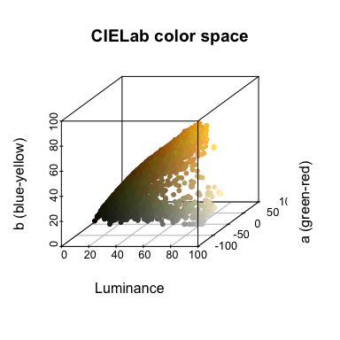

```r
colordistance::plotPixels(H1, lower = rep(0.8, 3), upper = rep(1, 1),
                          color.space = "lab", ref.white = "D65",
                          main = "CIELab color space",
                          ylim = c(-100, 100), zlim = c(0, 100))
```

## Clustering in CIELab space

Like RGB and HSV, `colordistance` provides both a histogram binning method and a K-means clustering method for grouping colors together. Note that the histogram binning method uses a different function, `getLabHist` rather than `getImageHist`.

The major differences with `getLabHist` are that it requires the specification of a reference white, and that it gives you the option of setting the ranges for the a and b channels of CIELab space. Unlike RGB, where each channel invariably ranges from 0 to 1, the a and b channels of CIELab are theoretically unbounded. They are usually between -128 and 127, but depending on the reference white may have much narrower ranges than this. There’s no real harm in having boundaries that fall well outside the actual range of the data, but it does have a small impact on both speed and precision.

```r
par(mfrow = c(1, 2))
# Setting boundaries
lab_hist <- colordistance::getLabHist(image_paths[1], bins = 3,
                                      sample.size = 10000, ref.white = "D65", bin.avg = TRUE,
                                      plotting = TRUE, lower = rep(0.8, 3), upper = rep(1, 3),
                                      a.bounds = c(-100, 100), b.bounds = c(-100, 100))
```

```
#> Accuracy of CIE Lab color space depends on specification of an appropriate white reference. See 'Color spaces' vignette for more information.
#> From reference white:
#> To reference white: D65
#> Converting 10000 randomly selected pixel(s) from sRGB color space to Lab color space
#> Using 3^3 = 27 total bins
```

```
#> Accuracy of CIE Lab color space depends on specification of an appropriate white reference. See 'Color spaces' vignette for more information.
#> From reference white:
#> To reference white: D65
#> Converting 10000 randomly selected pixel(s) from sRGB color space to Lab color space
#> Using 3^3 = 27 total bins
```

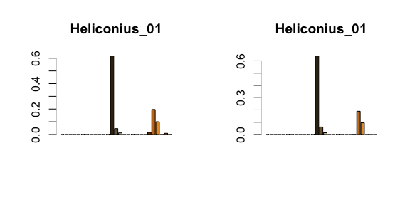

```r
# Leaving default boundaries (minor difference)
lab_hist <- colordistance::getLabHist(image_paths[1], bins = 3,
                                      sample.size = 10000, ref.white = "D65", bin.avg = TRUE,
                                      plotting = TRUE, lower = rep(0.8, 3), upper = rep(1, 3))
```

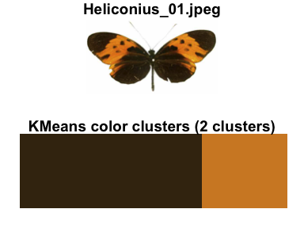

```r
lab_kmeans <- colordistance::getKMeanColors(image_paths[1], n = 2, sample.size = 10000,
                                            lower = rep(0.8, 3), upper = rep(1, 3),
                                            color.space = "CIELab", ref.white = "D65")
```